# HMIS R Demo

# Simple R markdown file to show some database interaction, aggregation, and very basic plotting using HMIS data from public records request that is stored in a local PostgreSQL database

### At a high level, this markdown is an example of working with HMIS data, calculating a couple simple aggregates and measures, then creating flat file output files. This is formatted into a R Markdown file to make it easier to follow, could be migrated into a normal R script rather easily.

```r
# bring in needed libraries
library(RPostgreSQL)
library(dplyr)
library(tidyverse)
```

# Bring in config for database connection params. Establish a connection to db, and get a list of tables in the default schema -> “public” in this case

```r
source("config.R")

con = RPostgreSQL::dbConnect(dbDriver("PostgreSQL"), dbname='sac_hmis', host='localhost',
                             port=5432, user=user, password=pass)

RPostgreSQL::dbListTables(con)
```

```
##  [1] "exit_screen"            "clients"                "assessment"
##  [4] "programs"               "enrollment"             "destinations"
##  [7] "yearly_race"            "race_no_prog"           "age_no_prog"
## [10] "age_prog"               "gender_no_prog"         "yearly_gender"
## [13] "volume_active_programs" "volume_active"          "volume_total_programs"
## [16] "volume_total"           "num_to_ph"              "outcomes_sum_monthly"
## [19] "outcomes_sum_yearly"    "yearly_race_temp"       "yearly_race_temp"
## [22] "yearly_race_temp"
```

# Grab a couple tables from the databse (source tables - have aggregate tables calculated with sql in local database too)

```r
# dplyr doesn't actually store these in memory until collect() is called -> all aggregate functions get turned into sql qeuries that get executed when the data is needed

destinations <- tbl(con, 'destinations')
destinations
```

```
## # Source:   table<destinations> [?? x 2]
## # Database: postgres 12.0.3 [postgres@localhost:5432/sac_hmis]
##    Destination_Code Exit_Destination
##               <int> <chr>
##  1                4 Client doesn't know
##  2                4 Client refused
##  3                4 Data not collected
##  4                5 Deceased
##  5                2 Emergency shelter, including hotel or motel paid for with e~
##  6                6 Foster care home or foster care group home
##  7                6 Hospital or other residential non-psychiatric medical facil~
##  8                2 Hotel or motel paid for without emergency shelter voucher
##  9                6 Jail, prison or juvenile detention facility
## 10                6 Long-term care facility or nursing home
## # ... with more rows
```

```r
# library for running raw sql queries rather than having dplyr create them for you -> some functions get a bit weird when converted
library(DBI)
```

# Grab the exit screens table

```r
exits <- dplyr::tbl(con, "exit_screen")
exits
```

```
## # Source:   table<exit_screen> [?? x 6]
## # Database: postgres 12.0.3 [postgres@localhost:5432/sac_hmis]
##     Client_Id Enrollment_Id Exit_Destination        Exit_Reason Exit_Date  es_id
##         <dbl>         <dbl> <chr>                   <chr>       <date>     <dbl>
##  1    9692964    9389092022 Staying or living with~ Completed ~ 2019-12-10     1
##  2 1805315895   11366024585 Permanent housing (oth~ Completed ~ 2019-10-08     2
##  3  790450659   10775929394 Data not collected      Other       2019-09-07     3
##  4 3094211101   11074665541 Rental by client, no o~ Completed ~ 2019-08-31     4
##  5 3163904393   11078535393 Rental by client, no o~ Completed ~ 2019-08-31     5
##  6 3163904394   11078833101 Rental by client, no o~ Completed ~ 2019-08-31     6
##  7 2744406716   10381758535 Rental by client, no o~ Completed ~ 2019-08-31     7
##  8 3011308830   10387667331 Rental by client, no o~ Completed ~ 2019-08-31     8
##  9 2857190606   10639978611 Rental by client, no o~ Completed ~ 2019-08-31     9
## 10 3051486396   10644501293 Rental by client, no o~ Completed ~ 2019-08-31    10
## # ... with more rows
```

# Summarize 2019 exit destinations - order by number of people exiting to that destination

```r
measure <- exits %>% filter(
  (Exit_Date > "2018-12-31" && Exit_Reason == "Completed Program")) %>% group_by(
    Exit_Destination
    ) %>% summarise(
                    NumExit = n()
                    ) %>% arrange(
                      desc(NumExit)
                    ) %>% collect() # collect method brings the data  returned from sql query into memory ->
                                    # if not done, further aggregations are added to the generated sql and can get a bit strange
measure
```

```
## # A tibble: 33 x 2
##    Exit_Destination                                                      NumExit
##    <chr>                                                                   <dbl>
##  1 Rental by client, no ongoing housing subsidy                              847
##  2 Place not meant for habitation (e.g., a vehicle, an abandoned buildi~     298
##  3 Rental by client, with other ongoing housing subsidy                      292
##  4 Permanent housing (other than RRH) for formerly homeless persons          255
##  5 Staying or living with family, permanent tenure                           199
##  6 Rental by client, with VASH housing subsidy                               185
##  7 Transitional housing for homeless persons (including homeless youth)      180
##  8 Emergency shelter, including hotel or motel paid for with emergency ~     104
##  9 Rental by client, with RRH or equivalent subsidy                           75
## 10 Staying or living with friends, permanent tenure                           58
## # ... with 23 more rows
```

# Show the possible Exit Destinations to choose a few to plot

```r
measure$Exit_Destination
```

```
##  [1] "Rental by client, no ongoing housing subsidy"
##  [2] "Place not meant for habitation (e.g., a vehicle, an abandoned building, bus/train/subway station/airport or anywhere outside)"
##  [3] "Rental by client, with other ongoing housing subsidy"
##  [4] "Permanent housing (other than RRH) for formerly homeless persons"
##  [5] "Staying or living with family, permanent tenure"
##  [6] "Rental by client, with VASH housing subsidy"
##  [7] "Transitional housing for homeless persons (including homeless youth)"
##  [8] "Emergency shelter, including hotel or motel paid for with emergency shelter voucher, or RHY-funded Host Home shelter"
##  [9] "Rental by client, with RRH or equivalent subsidy"
## [10] "Staying or living with friends, permanent tenure"
## [11] "Other"
## [12] "Staying or living with family, temporary tenure (e.g. room, apartment or house)"
## [13] "Staying or living with friends, temporary tenure (e.g. room, apartment or house)"
## [14] "Hotel or motel paid for without emergency shelter voucher"
## [15] "Safe Haven"
```

[output cut: 18 more lines]

# Limit the available options for exit destinations to a few I’m interested in and plot those - quickly limit the length of the labels so the plot can still render in the frame.

### Visualization isn’t a key aspect of this role, however worth quickly visualizing some basic trends in the data.

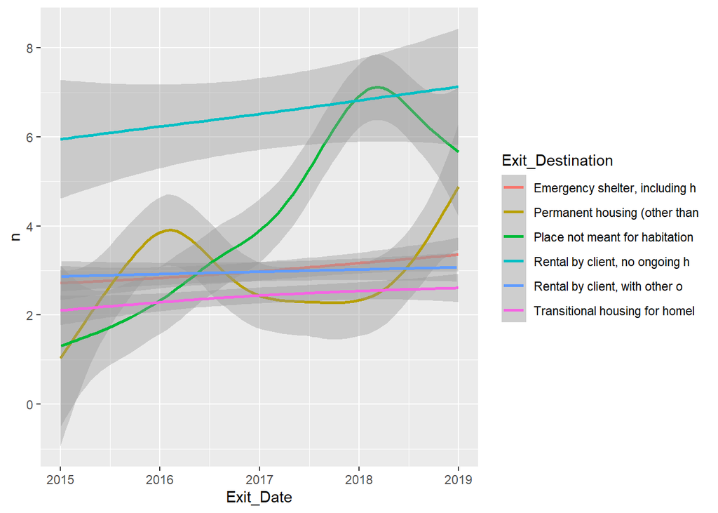

```r
outcomes <- c('Rental by client, no ongoing housing subsidy','Rental by client, with other ongoing housing subsidy','Permanent housing (other than RRH) for formerly homeless persons', 'Transitional housing for homeless persons (including homeless youth)', 'Emergency shelter, including hotel or motel paid for with emergency shelter voucher, or RHY-funded Host Home shelter', 'Place not meant for habitation (e.g., a vehicle, an abandoned building, bus/train/subway station/airport or anywhere outside)')

forPlot <- exits %>% filter(
  Exit_Date >= "2015-01-01" &&
    Exit_Date < "2019-01-01" &&
    Exit_Destination %in% outcomes)%>% group_by(Exit_Date, Exit_Destination) %>% summarize(n = n()) %>% arrange(Exit_Date) %>% collect() %>% mutate(Exit_Destination=
                                                                                                                                        str_trunc(Exit_Destination, 30, "right", ""))
# show a line plot of the num people exiting per day to each destination since 2015


ggplot(data = forPlot, mapping = aes(x = Exit_Date, y = n))  + geom_smooth(mapping = aes(color = Exit_Destination))
```

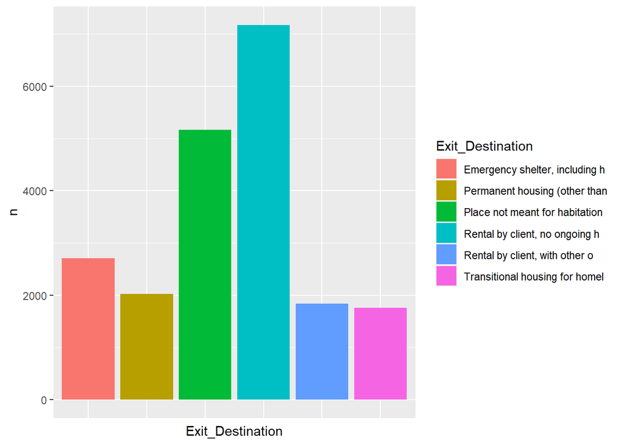

```r
# show a bar plot of total exits to each destination
ggplot(data = forPlot) + geom_bar(mapping=aes(x=Exit_Destination, y=n, fill=Exit_Destination), stat='identity') + theme(axis.text.x=element_blank(),
                                                                                                              axis.ticks.x=element_blank())
```

# Get a list of the distinct exit reasons to choose a few to plot

```r
a <- exits %>% filter(!is.na(Exit_Reason)) %>% group_by(Exit_Reason) %>% summarise(n()) %>% collect()
a$Exit_Reason
```

```
##  [1] "Other"
##  [2] "Non-payment of rent/occupancy charge"
##  [3] "Death"
##  [4] "Disagreement with rules/persons"
##  [5] "Reached maximum time allowed by program"
##  [6] "Needs could not be met by program"
##  [7] "Left for a housing opportunity before completing program"
##  [8] "Criminal activity/destruction of property/violence"
##  [9] "Completed Program"
## [10] "Unknown/disappeared"
## [11] "Non-compliance with program"
```

# Plot the trend in daily exits for a few select exit reasons, then plot a bar of the total number of exits due to the reasons in bar chart.

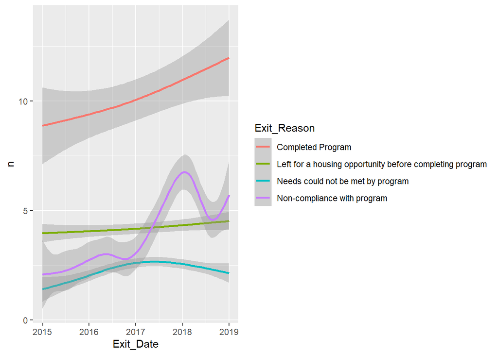

```r
reasons  <- c('Completed Program','Non-compliance with program','Needs could not be met by program','Left for a housing opportunity before completing program')

forPlot <- exits %>% filter(
  Exit_Date >= "2015-01-01" &&
    Exit_Date < "2019-01-01" &&
    Exit_Reason %in% reasons)%>% group_by(Exit_Date, Exit_Reason) %>% summarize(n = n()) %>% arrange(Exit_Date) %>% collect()

ggplot(data = forPlot, mapping = aes(x = Exit_Date, y = n))  + geom_smooth(mapping = aes(color = Exit_Reason))
```

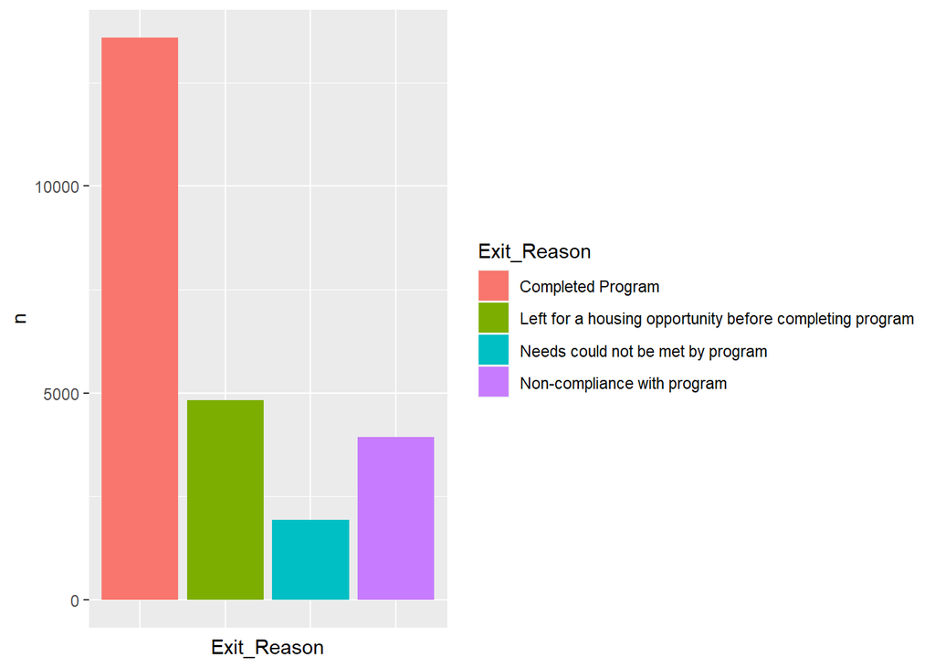

```r
ggplot(data = forPlot) + geom_bar(mapping=aes(x=Exit_Reason, y=n, fill=Exit_Reason), stat='identity') + theme(axis.text.x=element_blank(),
                                                                                                              axis.ticks.x=element_blank())
```

# Look at the clients table

```r
clients <- tbl(con, "clients")
clients
```

```
## # Source:   table<clients> [?? x 9]
## # Database: postgres 12.0.3 [postgres@localhost:5432/sac_hmis]
##    Race  Ethnicity Gender Vet_Status Vet_Discharge_S~ Created_Date Updated_Date
##    <chr> <chr>     <chr>  <chr>      <chr>            <date>       <date>
##  1 White Non-Hisp~ Female No         <NA>             2009-10-22   2010-02-06
##  2 Blac~ Non-Hisp~ Male   <NA>       <NA>             2019-08-22   2019-08-22
##  3 White Non-Hisp~ Male   <NA>       <NA>             2019-08-01   2019-08-01
##  4 White Hispanic~ Male   <NA>       <NA>             2019-07-29   2019-08-23
##  5 Blac~ Non-Hisp~ Female <NA>       <NA>             2019-07-10   2019-07-10
##  6 Blac~ Non-Hisp~ Male   <NA>       <NA>             2019-07-11   2019-07-11
##  7 Mult~ Hispanic~ Male   <NA>       <NA>             2019-07-25   2019-07-25
##  8 Blac~ Hispanic~ Female <NA>       <NA>             2019-06-21   2019-08-14
##  9 White Non-Hisp~ Female <NA>       <NA>             2019-08-15   2019-08-15
## 10 Blac~ Non-Hisp~ Female <NA>       <NA>             2019-07-15   2019-07-18
## # ... with more rows, and 2 more variables: Birth_Date <date>, Client_Id <dbl>
```

# Summarize the Age demographics, grouped by Race from 2017 on. Using dplyr here to generate the query, next cell uses DBI package to execute a raw sql query on the database.

## Summarize the age by the mean, max, min, and median age values. Here the “age” function used in the “mutate” function is actually a sql function, not an R function. Example of how sometimes using the SQL generated by dplyr can be challenging for legacy code to be passed along without communication.

```r
race <- clients %>% filter(Created_Date >= "2017-01-01") %>%mutate(age=(age(Birth_Date, now())))  %>% group_by(Race) %>% summarize(
  n = n(),
  meanAge = sum(age * (-1)) / count(1),
  medianAge = median(age * (-1)),
  minAge = min(age * (-1)),
  maxAge = max(age * (-1))
)%>%arrange(
  desc(n)
)%>%show_query() # adding show_query() at end of dplyr pipes can help dubug confusing aggregations in legacy code
```

```
## <SQL>
## SELECT "Race", COUNT(*) AS "n", SUM("age" * (-1.0)) / count(1.0) AS "meanAge", PERCENTILE_CONT(0.5) WITHIN GROUP (ORDER BY "age" * (-1.0)) AS "medianAge", MIN("age" * (-1.0)) AS "minAge", MAX("age" * (-1.0)) AS "maxAge"
## FROM (SELECT "Race", "Ethnicity", "Gender", "Vet_Status", "Vet_Discharge_Status", "Created_Date", "Updated_Date", "Birth_Date", "Client_Id", (age("Birth_Date", CURRENT_TIMESTAMP)) AS "age"
## FROM (SELECT *
## FROM "clients"
## WHERE ("Created_Date" >= '2017-01-01')) "dbplyr_001") "dbplyr_002"
## GROUP BY "Race"
## ORDER BY "n" DESC
```

```r
race
```

```
## # Source:     lazy query [?? x 6]
## # Database:   postgres 12.0.3 [postgres@localhost:5432/sac_hmis]
## # Ordered by: desc(n)
##   Race              n meanAge         medianAge       minAge       maxAge
##   <chr>         <dbl> <chr>           <chr>           <chr>        <chr>
## 1 White          6275 37 years 11 mo~ 38 years 8 mon~ 1 year 8 mo~ 100 years 8 ~
## 2 Black or Afr~  6092 28 years 6 mon~ 25 years 8 mon~ 1 year 8 mo~ 87 years 8 m~
## 3 Multi-racial   1021 23 years 2 mon~ 17 years 8 mon~ 1 year 8 mo~ 89 years 8 m~
## 4 American Ind~   314 40 years 4 mon~ 41 years 8 mon~ 1 year 8 mo~ 94 years 8 m~
## 5 Asian           229 33 years 5 mon~ 33 years 8 mon~ 2 years 8 m~ 94 years 8 m~
## 6 Native Hawai~   219 34 years 3 mon~ 33 years 8 mon~ 2 years 8 m~ 76 years 8 m~
## 7 Unknown         213 36 years 1 mon~ 33 years 8 mon~ 1 year 8 mo~ 78 years 8 m~
```

# Now gather the same data as above, but use a raw sql query. Using the query allows me to more easily also add in the 1st and 3rd quartiles in the summary of the age distribution within the race groups.

# These age calculations are the age of the client on the day they were added to the clients table, assuming that’s what “Created_Date” indicates.

```r
sql = "select \"Race\"
, avg((TO_CHAR(\"Created_Date\"::DATE, 'YYYY')::INTEGER - to_char(\"Birth_Date\", 'YYYY')::INTEGER)) meanAge
, min((TO_CHAR(\"Created_Date\"::DATE, 'YYYY')::INTEGER - to_char(\"Birth_Date\", 'YYYY')::INTEGER)) minAge
, PERCENTILE_DISC(0.5) WITHIN GROUP (ORDER BY ((TO_CHAR(\"Created_Date\"::DATE, 'YYYY')::INTEGER - to_char(\"Birth_Date\", 'YYYY')::INTEGER))) medianAge
, PERCENTILE_DISC(0.25) WITHIN GROUP (ORDER BY ((TO_CHAR(\"Created_Date\"::DATE, 'YYYY')::INTEGER - to_char(\"Birth_Date\", 'YYYY')::INTEGER))) lowerQuartile
, PERCENTILE_DISC(0.75) WITHIN GROUP (ORDER BY ((TO_CHAR(\"Created_Date\"::DATE, 'YYYY')::INTEGER - to_char(\"Birth_Date\", 'YYYY')::INTEGER))) upperQuartile
, max((TO_CHAR(\"Created_Date\"::DATE, 'YYYY')::INTEGER - to_char(\"Birth_Date\", 'YYYY')::INTEGER)) maxAge
, COUNT(*) n
from clients
WHERE (TO_CHAR(\"Created_Date\"::DATE, 'YYYY')::INTEGER - to_char(\"Birth_Date\", 'YYYY')::INTEGER >= 0
AND TO_CHAR(\"Created_Date\"::DATE, 'YYYY')::INTEGER - to_char(\"Birth_Date\", 'YYYY')::INTEGER <= 85
AND TO_CHAR(\"Created_Date\", 'YYYY')::INTEGER = 2017)
group by \"Race\"
order by n desc"


raceRawSQL = dbGetQuery(con, sql)

raceRawSQL
```

```
##                                        Race  meanage minage medianage
## 1                 Black or African American 25.00436      0        22
## 2                                     White 34.25230      0        35
## 3                              Multi-racial 18.84580      0        13
## 4          American Indian or Alaska Native 32.56557      0        32
## 5 Native Hawaiian or Other Pacific Islander 28.53409      1        29
## 6                                     Asian 28.96154      0        32
## 7                                   Unknown 30.46429      1        24
##   lowerquartile upperquartile maxage    n
## 1             8            38     77 2295
## 2            21            50     84 2283
## 3             4            29     81  441
## 4            19            48     79  122
## 5            13            40     73   88
## 6            12            40     63   78
## 7            20            43     59   28
```

# Create a custom operator - to generate some formatted queries for me. Using the operator allows me to vectorize the function calls and not need to bulid a loop in order to generate the queries I need.

```r
# formatter operator
# requires strings to have %s where values should be filled
'%f%' <- function(x,y) {
  do.call(sprintf, c(list(x), y))
}

# examples
sql1 <- "SELECT * FROM clients WHERE to_char(\"Created_Date\", 'YYYY')::INTEGER = %s" %f% list(2015:2019)
paste('####SQL1####')
```

```
## [1] "####SQL1####"
```

```r
paste(sql1)
```

```
## [1] "SELECT * FROM clients WHERE to_char(\"Created_Date\", 'YYYY')::INTEGER = 2015"
## [2] "SELECT * FROM clients WHERE to_char(\"Created_Date\", 'YYYY')::INTEGER = 2016"
## [3] "SELECT * FROM clients WHERE to_char(\"Created_Date\", 'YYYY')::INTEGER = 2017"
## [4] "SELECT * FROM clients WHERE to_char(\"Created_Date\", 'YYYY')::INTEGER = 2018"
## [5] "SELECT * FROM clients WHERE to_char(\"Created_Date\", 'YYYY')::INTEGER = 2019"
```

```r
years <- list(2015:2019)
races <- 'Unknown'

sql2 <- "SELECT * FROM clients WHERE to_char(\"Created_Date\", 'YYYY')::INTEGER = %s AND \"Race\" = '%s' " %f% c(years,races)


paste('####SQL2####')
```

```
## [1] "####SQL2####"
```

```r
paste(sql2)
```

```
## [1] "SELECT * FROM clients WHERE to_char(\"Created_Date\", 'YYYY')::INTEGER = 2015 AND \"Race\" = 'Unknown' "
## [2] "SELECT * FROM clients WHERE to_char(\"Created_Date\", 'YYYY')::INTEGER = 2016 AND \"Race\" = 'Unknown' "
## [3] "SELECT * FROM clients WHERE to_char(\"Created_Date\", 'YYYY')::INTEGER = 2017 AND \"Race\" = 'Unknown' "
## [4] "SELECT * FROM clients WHERE to_char(\"Created_Date\", 'YYYY')::INTEGER = 2018 AND \"Race\" = 'Unknown' "
## [5] "SELECT * FROM clients WHERE to_char(\"Created_Date\", 'YYYY')::INTEGER = 2019 AND \"Race\" = 'Unknown' "
```

# Create a quick loop for running queries that summarize the age stats for each year from 2015-2019.

## Output a flat file of each summary year with the year formatted into title

### All above summary tables could easily be output to flat files with the same write.csv() funciton.

```r
years <- list(2015:2019)

sqlArray = "select \"Race\"
, avg((TO_CHAR(\"Created_Date\"::DATE, 'YYYY')::INTEGER - to_char(\"Birth_Date\", 'YYYY')::INTEGER)) meanAge
, min((TO_CHAR(\"Created_Date\"::DATE, 'YYYY')::INTEGER - to_char(\"Birth_Date\", 'YYYY')::INTEGER)) minAge
, max((TO_CHAR(\"Created_Date\"::DATE, 'YYYY')::INTEGER - to_char(\"Birth_Date\", 'YYYY')::INTEGER)) maxAge
, PERCENTILE_DISC(0.5) WITHIN GROUP (ORDER BY ((TO_CHAR(\"Created_Date\"::DATE, 'YYYY')::INTEGER - to_char(\"Birth_Date\", 'YYYY')::INTEGER))) medianAge
, PERCENTILE_DISC(0.25) WITHIN GROUP (ORDER BY ((TO_CHAR(\"Created_Date\"::DATE, 'YYYY')::INTEGER - to_char(\"Birth_Date\", 'YYYY')::INTEGER))) lowerQuartile
, PERCENTILE_DISC(0.75) WITHIN GROUP (ORDER BY ((TO_CHAR(\"Created_Date\"::DATE, 'YYYY')::INTEGER - to_char(\"Birth_Date\", 'YYYY')::INTEGER))) upperQuartile
, COUNT(*) n
from clients
WHERE (TO_CHAR(\"Created_Date\"::DATE, 'YYYY')::INTEGER - to_char(\"Birth_Date\", 'YYYY')::INTEGER >= 0
AND TO_CHAR(\"Created_Date\"::DATE, 'YYYY')::INTEGER - to_char(\"Birth_Date\", 'YYYY')::INTEGER <= 85
AND TO_CHAR(\"Created_Date\", 'YYYY')::INTEGER = %s)
group by \"Race\"
order by n desc" %f% years

dataframes <- list()
yearVec = c(2015:2019)
for(index in 1:length(sqlArray)) {
  data <- dbGetQuery(con, sqlArray[index])
  data$meanage <- floor(data$meanage) # round down their year age
  dataframes[[index]] <- data
  write.csv(x = data, file = 'Race_Age_Summary_%s.csv'%f% yearVec[index])
}

print(dataframes)
```

```
## [[1]]
##                                        Race meanage minage maxage medianage
## 1                                     White      35      0     81        37
## 2                 Black or African American      26      0     85        24
## 3                              Multi-racial      21      0     77        17
## 4          American Indian or Alaska Native      34      1     74        35
## 5 Native Hawaiian or Other Pacific Islander      25      0     66        26
## 6                                     Asian      32      1     63        36
## 7                                   Unknown      44     24     68        46
##   lowerquartile upperquartile    n
## 1            22            50 2161
## 2             8            41 1939
## 3             4            37  281
## 4            25            48  102
## 5             5            40   80
```

[output cut: 74 more lines]

# Generate query for getting program info joined to enrollments

```r
sql = "
SELECT b.\"Program_Id\", b.\"Agency_Id\", b.\"Program_Name\", b.\"Project_Type_Group\",
a.\"Client_Id\", a.\"Added_Date\", a.\"Zip\", a.\"Chronic_Homeless\", a.\"Prior_Residence\",
to_char(a.\"Added_Date\", 'YYYY')::INTEGER as Added_year
from enrollment a
left join programs b
on a.\"Program_Id\" = b.\"Program_Id\"
where b.\"Program_End\" is not null
and to_char(a.\"Added_Date\", 'YYYY')::INTEGER > 2014
"

enrollmentPrograms <- dbGetQuery(con, sql)

enrollmentPrograms %>% head()
```

```
##   Program_Id Agency_Id                                       Program_Name
## 1        272         5 VOA: CATC (Comprehensive Alcohol Treatment Center)
## 2        272         5 VOA: CATC (Comprehensive Alcohol Treatment Center)
## 3        272         5 VOA: CATC (Comprehensive Alcohol Treatment Center)
## 4        272         5 VOA: CATC (Comprehensive Alcohol Treatment Center)
## 5        272         5 VOA: CATC (Comprehensive Alcohol Treatment Center)
## 6        272         5 VOA: CATC (Comprehensive Alcohol Treatment Center)
##   Project_Type_Group  Client_Id Added_Date Zip Chronic_Homeless
## 1              Other  326313790 2016-02-09  NA               No
## 2              Other   11543597 2016-02-11  NA               No
## 3              Other  613745077 2016-02-26  NA               No
## 4              Other 1537491844 2016-03-09  NA               No
## 5              Other 1863950043 2016-03-14  NA               No
## 6              Other 1885503905 2016-03-28  NA               No
##                                                   Prior_Residence added_year
## 1                    Rental by client, no ongoing housing subsidy       2016
## 2 Staying or living in a family member's room, apartment or house       2016
## 3        Staying or living in a friend's room, apartment or house       2016
## 4                    Rental by client, no ongoing housing subsidy       2016
## 5                    Rental by client, no ongoing housing subsidy       2016
## 6                    Rental by client, no ongoing housing subsidy       2016
```

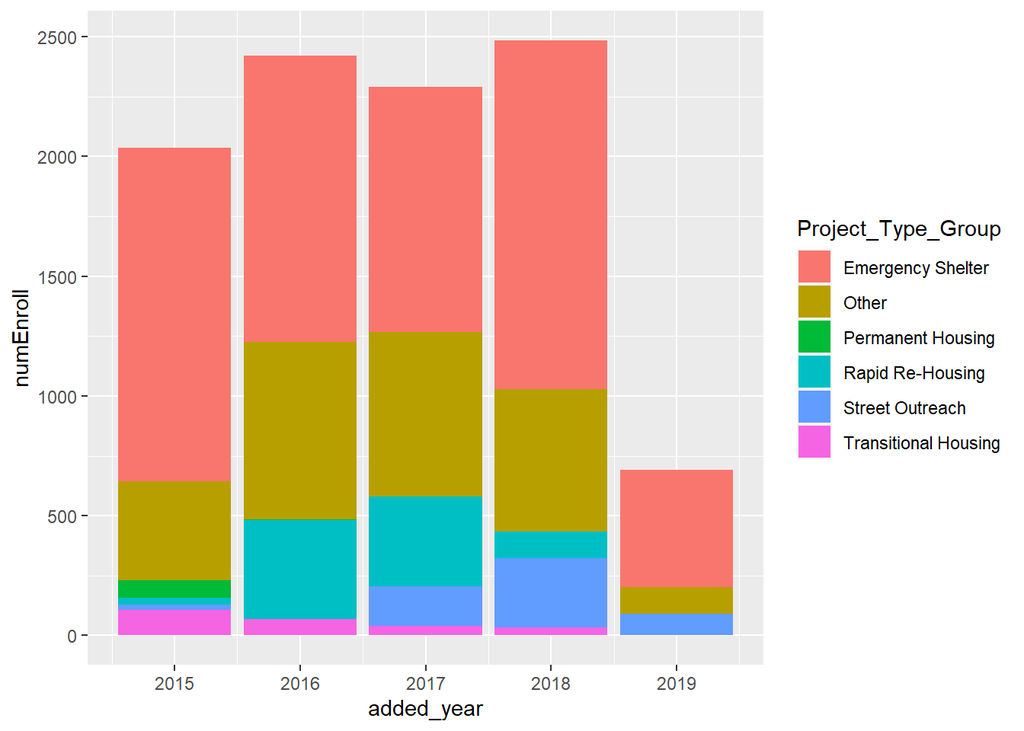

```r
project_type_group <- enrollmentPrograms %>% group_by(Project_Type_Group, added_year) %>%
                      summarise(numEnroll=n())

ggplot(data=project_type_group, mapping=aes(x=added_year)) + geom_bar(aes(y = numEnroll ,fill=Project_Type_Group), stat='identity')
```

# See if there is any interesting information related to the zip codes listed for the clients in the enrollment table

### Too few have a zip listed to gather any valuable info - at least in data provided in public records request.

```r
zips <- enrollmentPrograms %>% filter(!is.na(Zip)) %>% group_by(Zip) %>%
         summarise(numEnroll = n()) %>% arrange(desc(numEnroll))

zips
```

```
## # A tibble: 40 x 2
##      Zip numEnroll
##    <int>     <int>
##  1 95823        18
##  2 95825        18
##  3 95821        16
##  4 95815        10
##  5 95822        10
##  6 95828         9
##  7 95824         8
##  8 95833         7
##  9 95670         6
## 10 95758         6
## # ... with 30 more rows
```

# Created the following function in my postgreSQL database to allow for a for loop to be called in a function that I can call to make some querying a bit easier for reporting. This returns a table with summary of number of people enrolling per race per project type per year. Here is the sql that created that funciton:

```sql
drop function summarizeRace();
create or replace function summarizeRace()
returns table(date varchar,
             "Project_Type" varchar,
             "Race" varchar,
             num_people_enroll int)
LANGUAGE 'plpgsql'
as $$
declare
rec RECORD;
begin
DROP table if exists yearly_race_temp;
    create temp table yearly_race_temp
            (date varchar,
             "Project_Type" varchar,
             "Race" varchar,
             num_people_enroll int);
    FOR rec in
    (SELECT DISTINCT to_char("Added_Date", 'YYYY') as yearvar FROM enrollment
        WHERE to_char("Added_Date", 'YYYY') > '2014')
    LOOP
        INSERT INTO yearly_race_temp
            SELECT rec.yearvar::text as Date,
            p."Project_Type_Group" as "Project_Type",
            c."Race",
            COUNT(distinct e."Client_Id") Num_People_Enroll
            FROM enrollment e
            LEFT JOIN clients c
            ON e."Client_Id" = c."Client_Id"
            left join programs p
            on e."Program_Id" = p."Program_Id"
            left join exit_screen ex on ex."Enrollment_Id" = e."Enrollment_Id"
            WHERE e."Added_Date" <> '2014-01-01'
            AND TO_CHAR(e."Added_Date", 'YYYY') <= rec.yearvar::text
            and (ex."Exit_Date" > cast((rec.yearvar::text || '-01-01') as date)
                OR ex."Exit_Date" IS NULL)
            GROUP BY date, p."Project_Type_Group", c."Race"
            ORDER BY date, p."Project_Type_Group";
    END LOOP;
     RETURN QUERY
     SELECT * from yearly_race_temp;
 END $$;
```

#Use the function and get the results, write simple summary to csv. Won’t be outputting any more flat files, just a final example of how simple the flat file output is.

```r
yearlyRace <- dbGetQuery(con, 'SELECT * from summarizeRace()')
yearlyRace %>% head()
```

```
##   date      Project_Type                                      Race
## 1 2019 Emergency Shelter          American Indian or Alaska Native
## 2 2019 Emergency Shelter                                     Asian
## 3 2019 Emergency Shelter                 Black or African American
## 4 2019 Emergency Shelter                              Multi-racial
## 5 2019 Emergency Shelter Native Hawaiian or Other Pacific Islander
## 6 2019 Emergency Shelter                                   Unknown
##   num_people_enroll
## 1                75
## 2                59
## 3              1094
## 4               193
## 5                37
## 6                48
```

```r
write.csv(x=yearlyRace, file='yearlyRace_Program_Enrollment.csv')
```